# MATH5741M: Statistical Theory and Methods

Benjamin Thorpe

2021-10-10

Benjamin Thorpe (b.thorpe@leeds.ac.uk)  
Sunday October 10, 2021

# 3 Statistical Models

As discussed in Chapter 1, statistics is relevant to all natural and social sciences. We will now use an example from criminology to illustrate the basics of statistical modelling. The data set `killers.Rdata` on Minerva is derived from a sample of observations taken from the Radford/FGCU Serial Killer Database.[^1] This database, which now consists of data on $4743$ different murderers, was started in 1992 and has the following goal:

*“Utilizing over 175 data points, multiple-murderer methodology, victimology and statistical analysis; researchers and Law Enforcement Agencies can build case studies and statistical profiles to further research the details of these crimes.”* - http://skdb.fgcu.edu/info.asp

A serial killer is defined as someone who has unlawfully committed at least two separate homicides over a period of time (not in the same event). According to the database, there were more than $900$ serial killers in the USA who first killed during the $1970$s or $1980$s, with thousands of murders attributed to them. We consider a random sample of $n = 100$ such killers.

We can see the first six rows by typing `killers[1:6, ]` into R. Each row contains the data of a single serial killer. Typing in `nrow(killers)` we see that there are $100$ in total here. We have $9$ pieces of information for each. In other words, we have a sample that consists of $100$ realisations for each of $9$ random variables.

```r
load("killers.Rdata")
killers[1:6,]
```

```
##    Sex  Race NumberOfVics AgeFirstKill AgeLastKill TotalConfessedKills
## 1 Male White           26         13.9        20.4                  25
## 2 Male White           23         28.4        31.7                  22
## 3 Male White           18         14.2        17.4                  19
## 4 Male Black           14         19.3        24.8                  14
## 5 Male Black           13         26.2        41.2                   0
## 6 Male White           13         26.0        31.2                   7
##   TotalConvictedKills YearsBetweenFirstAndLastKill YearFirstKill
## 1                   2                          6.5          1971
## 2                   2                          3.3          1983
## 3                   6                          3.2          1971
## 4                  14                          5.5          1981
## 5                   0                         15.0          1974
## 6                   7                          5.2          1978
```

These data should be fairly self explanatory. In the second row (row numbers are in the left margin), we see the data of a white man who, in his late twenties and early thirties, had $23$ victims in a span of $3.3$ years, starting in the year $1983$. He was convicted of only two murders, despite confessing to $22$.

## 3.1 Continuous variables

Random variables that can take any value in an interval of $\mathbb{R}$ are called “continuous”. Age at first kill is continuous because, in theory, it can take any value in $(0, \infty)$. Number of victims is not continuous because it must take integer values ($\sqrt{2}$ victims is impossible).

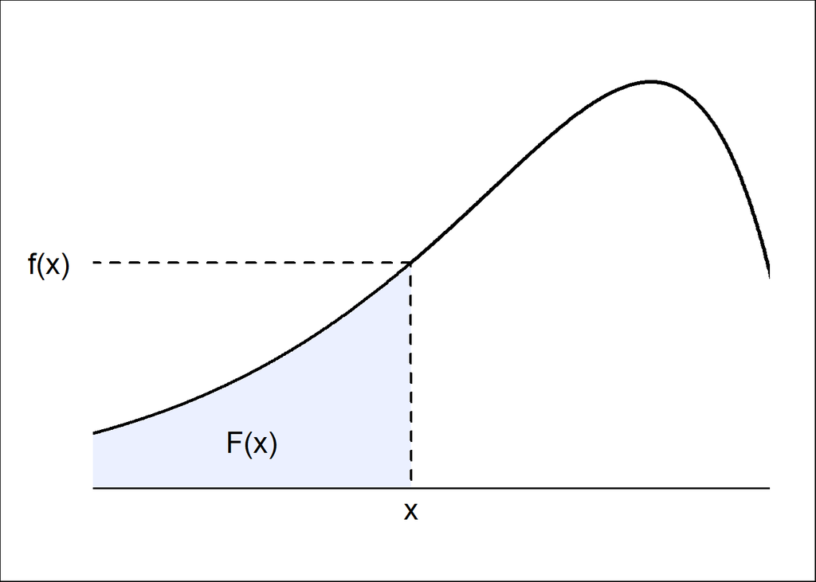

Figure 3.1: A density function $f(x)$ (plotted as a smooth curve) and distribution function $F(x)$ (shaded area under the curve).

We previously imagined probabilities for a random variable as areas under a curve, as in Figure 3.1. Suppose that the height of the curve at any $x$ is determined by some function $f(x)$. Then the probability of $X\leq x$ would be
$$\begin{eqnarray*}
{\mathsf P}(X \leq x) = {\mathsf P}(X \in (-\infty, x]) = \int_{-\infty}^{x}f(u)du,
\end{eqnarray*}$$
the area under the curve from $-\infty$ to $x$.

**Definition 3.1** A random variable $X$ is a **continuous random variable** if its cumulative distribution function $F(x) = {\mathsf P}(X \leq x)$ can be written as
$$\begin{eqnarray*}
F(x) & = &\int_{-\infty }^{x} f(u) du %\quad \text{for all }x\in \mathbb{R} \text{,}
\end{eqnarray*}$$
where $f:\mathbb{R} \rightarrow \mathbb{R}$ is a non-negative function. We call $f$ the **density function** of $X$.

We should always remember that
$$\begin{eqnarray*}
{\mathsf P}(X = x) = \int_{x}^{x} f(u) du = 0
\end{eqnarray*}$$
because the interval $[x,x]$ has zero width and therefore the corresponding area is zero. For example, if we model age as a continuous random variable, the model will assign zero probability to the event of a person being **exactly** $32$ years old.

We should also remember that, because $\mathbb{R} = (-\infty, \infty)$ corresponds to the entire sample space which must have probability $1$, we have
$$\begin{eqnarray*}
1 = {\mathsf P}(X \in \mathbb{R}) = \int_{-\infty}^{\infty} f(u)du
\end{eqnarray*}$$

${\mathsf P}(X = x) = 0$ has the important consequence that
$${\mathsf P}(X < x) = {\mathsf P}(X \leq x) = F(x)$$
for any $x$ and therefore
$$\begin{eqnarray*}
{\mathsf P}(X \in [a, b]) & = & {\mathsf P}(a \leq X \text{ and } X \leq b) \\
& = & {\mathsf P}(X \leq b) - {\mathsf P}(X < a) \\ & = & F(b) - F(a).
\end{eqnarray*}$$

Similarly,
$$\begin{eqnarray*}
{\mathsf P}(X \in (a, b)) & = & {\mathsf P}(a < X \text{ and } X < b)\\ & = & {\mathsf P}(X < b) - {\mathsf P}(X \leq a)\\ & = & F(b) - F(a).
\end{eqnarray*}$$
We can also easily show that ${\mathsf P}(X \in (a, b]) = F(b) - F(a)$ and ${\mathsf P}(X \in [a, b)) = F(b) - F(a)$. So, when we work with continuous random variables, we don’t need to worry too much about whether intervals are open or closed. However, this is **not** true for other types of random variable.

### 3.1.1 Normal distribution

**Example 3.1 (age at first kill)** Let’s consider a continuous variable: the age of a serial killer at the time of their first murder. Typing `hist(killers$AgeFirstKill)`into R produces the following histogram.

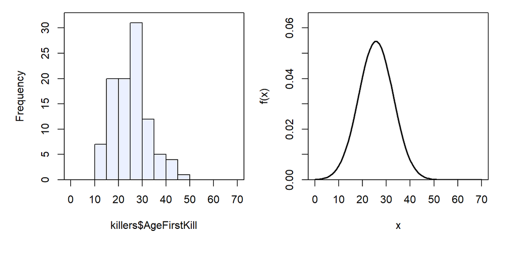

Figure 3.2: A histogram (left) of serial killer ages, showing a roughly bell-shaped distribution within our sample. A normal distribution density function (right) plotted as a smooth curve, with a similar shape to our histogram (symmetrical with similar location and spread).

There are many more serial killers than just those in our sample. How might we model this variable across the entire population of serial killers in the $1970$s and $1980$s? For a killer who was never caught and therefore whose age is unknown, how might we calculate the probability that they started at an age younger than $x =22$ years?

We should think of age at first kill as a random variable, $X$, and propose a density function, $f(x)$. Based on the histogram above, which gives us a rough idea of the shape of the curve produced by $f(x)$, it appears that a normal distribution might be appropriate.

**Definition 3.2** A random variable $X$ is said to have a **normal (or Gaussian) distribution** with mean parameter $\mu$ and variance parameter $\sigma^2$ if its density function is
$$f(x) =\dfrac{\exp\left[-{\left( x-\mu \right)^{2}/2\sigma^{2}} \right]}{\sqrt{2\pi\sigma^2}} \;.$$
We write $X\sim \text{N}(\mu,\sigma^{2})$.

**Solution to Example 3.1.** From our data, we might estimate $\mu\approx \overline{x} = 25.6$ and $\sigma \approx s = 7.3$ in R by typing

```r
mean(killers$AgeFirstKill)
```

```
## [1] 25.607
```

```r
sd(killers$AgeFirstKill)
```

```
## [1] 7.28046
```

It is not possible to write down the CDF, $F(x)$, of a normally distributed variable. Therefore we must rely on tables of approximate values for $F(x)$ or the R function `pnorm()`:

```r
pnorm(22, mean = 25.6, sd = 7.3)
```

```
## [1] 0.3109531
```

This tells us $F(22) \approx 0.31$, so there is approximately a $31\%$ chance that a killer starts before the age of $22$. If we want to do the same calculation by reading from tables, we will need the following definition and theorem.

**Definition 3.3** A random variable $Z \sim N(0, 1)$ with mean $0$ and variance $1$ is said to follow a **standard normal distribution** with density function
$$\phi(z) =\dfrac{\exp\left[-{z ^{2}/2} \right]}{\sqrt{2\pi}}.$$
Its cumulative distribution function is denoted $\Phi(z) = {\mathsf P}(Z \leq z)$.

**Theorem 3.1** If $X \sim N(\mu, \sigma^2)$ and if $a$ and $b$ are constants, then
$$aX + b \sim N(a\mu + b, a^2\sigma^2).$$
In particular,
$$Z = \frac{X - \mu}{\sigma} %= \left(\frac{1}{\sigma}\right)X + \left(-\frac{\mu}{\sigma}\right)
\sim N(0, 1).$$

For any $X \sim N(\mu, \sigma^2)$, if we want to obtain probabilities from tables then we must convert these into probabilities for $Z\sim N(0,1)$ by **standardising** $X$:
$$Z = \frac{X -\mu}{\sigma} \sim N(0, 1).$$

In our example, our model is assumed to be $X \sim N(25.6, 7.3^2)$ and we can write
$$\begin{eqnarray*}
{\mathsf P}\left(X \leq 22\right) & = & {\mathsf P}\left(\frac{X - \mu}{\sigma} \leq \frac{22 - \mu}{\sigma}\right)\\ & = & {\mathsf P}\left(Z \leq \frac{22 - 25.6}{7.3}\right)\\ & \approx & {\mathsf P}(Z \leq - 0.5).
\end{eqnarray*}$$
So we need to look up ${\mathsf P}(Z \leq - 0.5) = \Phi(-0.5)$ in the tables for $Z$.

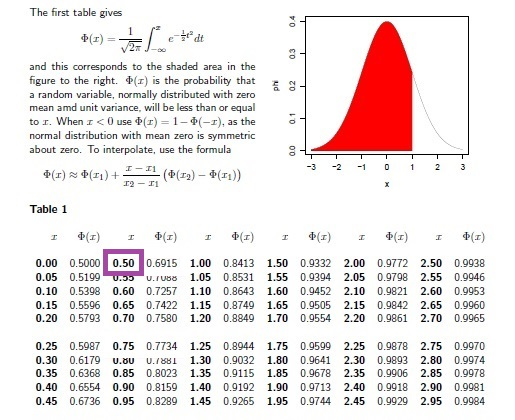

Figure 3.3: The standard normal distribution table used in recent exam papers for this module, with the probability ${\mathsf P}(Z \leq 0.5) = \Phi(0.5)$ highlighted.

The table doesn’t include $\Phi(-0.5)$, but it does give us $\Phi(0.5)$ and, by symmetry of the standard normal distribution about $0$, we get
$${\mathsf P}(Z \leq -0.5) = {\mathsf P}(Z \geq 0.5) = 1 - {\mathsf P}(Z < 0.5).$$
Therefore, reading $\Phi(z)$ from the table,
$$\begin{eqnarray*}
{\mathsf P}(Z \leq -0.5) & = & 1 - {\Phi(0.5)}\\
& \approx& 1 - 0.6915 \approx 31\%.
\end{eqnarray*}$$
So, just as we saw using R, there is approximately a $31\%$ chance that a killer starts before the age of $22$.

### 3.1.2 Exponential distribution

**Example 3.2 (career duration)** Now let’s consider another continuous variable: the time (in years) between the first and last kills of a serial killer. What is the probability that a “killing career” lasts more than ten years?

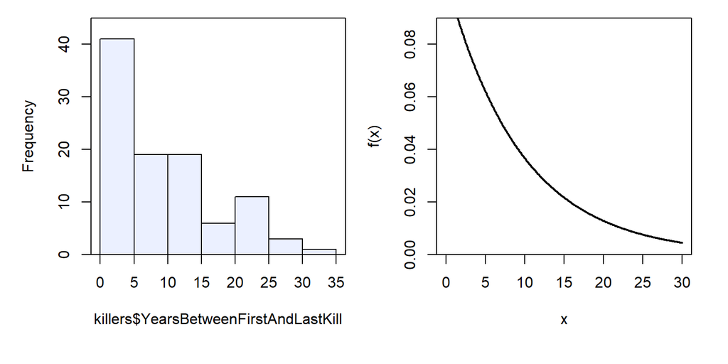

Figure 3.4: A histogram (left) of career durations, showing non-negative sample with clear positive skew. An exponential distribution density curve (right), with a similar shape to our histogram (non-negative with a positive skew).

The data here are very skewed, with a long tail to the right. If we plan to model this as a random variable, we will need a distribution that reflects this asymmetry. A normal distribution is not appropriate. We might consider an exponential distribution.

**Definition 3.4** A random variable $X$ is said to be **exponentially distributed** with rate parameter $\lambda > 0$ if its density function is
$$f(x) = \left\{ \begin{matrix}
\lambda\, e^{-\lambda x}& \text{if }x >0 \\
0 & \text{if }x \leq 0.
\end{matrix}\right.$$
We write $X \sim \text{Exp}(\lambda)$.

The exponential distribution is very often used to model time-to-event variables, specifically when an event occurs randomly and at a constant rate of $\lambda$ events per unit time. In health economics, it can be used to model the time between episodes of an illness. In physics, it describes the time until a radioactive particle decays.

### 3.1.3 Uniform distribution

**Example 3.3 (year of first murder)** Suppose we believe that a serial killer started murdering during the $70$s or $80$s. But suppose also that we don’t know the exact timing of their first murder. What is the probability that their first murder was in the first $2.5$ years of the $1980$s? In other words, letting $X$ denote time of first kill, what is
$${\mathsf P}(1980 \leq X \leq 1982.5)?$$
It might make sense to assume that any two time periods of the same length would be equally likely to produce a killer. In other words, that the starting dates of serial killers are roughly evenly spread over time. Our histogram seems to support this belief, since there is no clear pattern over time . The appropriate model would then be a uniform distribution, with a constant density function from $1970$ to $1990$.

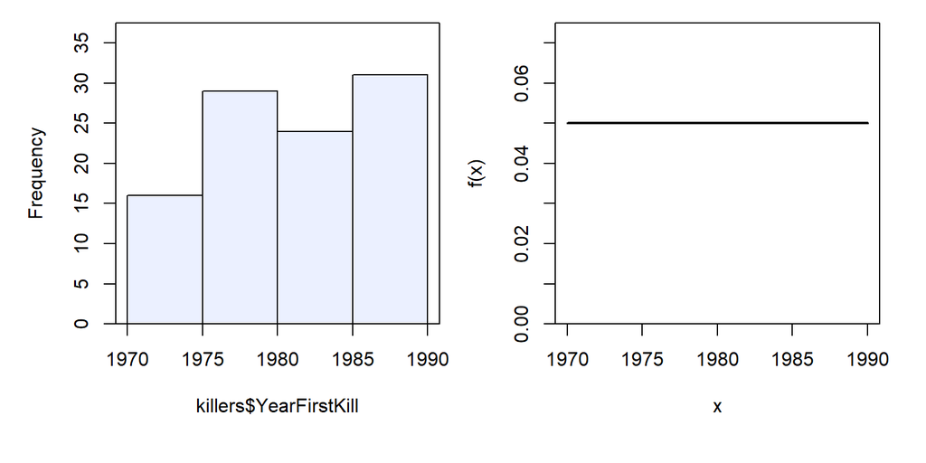

Figure 3.5: A histogram (left) of the years in which serial killers first murdered, showing a distribution without a clear shape. The frequencies in the $5$-year intervals do not appear to steadily increase or decrease over time and there is no obvious peak. Instead, the frequencies in each $5$-year interval appear to just vary randomly around a frequency of about $25$ killers (which corresponds to a density of $0.05$). A uniform distribution (right), with a constant density $0.05$ from $1970$ to $1990$ and zero density outside this interval.

**Definition 3.5** A random variable $X$ is said to be **uniformly distributed** on the interval $[a, b]$ if its density function is
$$f(x) = \left\{ \begin{matrix}
\dfrac{1}{b-a} & \text{if }x \in [a, b] \\
0 & \text{if }x \notin [a, b].
\end{matrix}\right.$$
We write $X \sim \text{U}[a,b]$.

**Solution to Example 3.3.** Assuming in our example that $X \sim \text{U}[1970, 1990]$, the probability that we want is
$$\begin{eqnarray*}
{\mathsf P}(1980 \leq X \leq 1982.5) & = & \int_{1980}^{1982.5}\frac{1}{1990-1970}dx \\
& = & \frac{1}{20}\int_{1980}^{1982.5}1dx\\
& = & 0.125,
\end{eqnarray*}$$
which is just $\text{(interval width)}/20$.

## 3.2 Discrete variables

Consider a random variable whose set of possible values is either finite or can be listed one-by-one in a sequence. We say the variable is “discrete” and that the set of possible values is “countable”. For example, we can list all integers in a sequence ($0, 1, -1, 2, -2, \ldots$) so the integers are countable. A variable such as number of victims can only take integer values and is therefore discrete. For this module, it is enough to just remember that any interval of real numbers is uncountable but any subset of the integers is countable.

For discrete random variables, using density functions and calculating probabilities as areas under curves would not make sense. For example, the probability of a serial killer having $3$ victims would then be
$${\mathsf P}(X = 3) = \int_{3}^{3}f(x)dx = 0.$$
For discrete random variables, we replace density functions with mass functions and, instead of calculating probabilities by integration, we calculate them by taking summations.

**Definition 3.6** A random variable $X$ is a **discrete random variable** if it can only take values in some countable set $J$. The function $f:\mathbb{R} \rightarrow \mathbb{R}$ defined by
$$\begin{equation*}
f(x)=\left\{
\begin{array}{cl}
{\mathsf P}(X=x) \text{} & \text{if }x\in J \\
0\text{} & \text{if }x\notin J
\end{array}
\right.
\end{equation*}$$
is the **mass function** of $X$.

The cumulative distribution function of a discrete random variable $X$ is
$$\begin{eqnarray*}
F(x) & = & {\mathsf P}(X \leq x)\\
& = & \sum_{j \leq x}{\mathsf P}(X = j)\\
& = & \sum_{j \leq x}f(j).
\end{eqnarray*}$$
We just add up the probabilities for all of the numbers $j \in J$ that are less than or equal to $x$. We should always remember that
$$\sum_{j \in J}f(j) = \sum_{j \in J}{\mathsf P}(X = j) = {\mathsf P}(X \in J) = 1.$$

We can see the difference between continuous and discrete random variables in Figure 3.6. Here we have a distribution with a similar shape to a normal curve, but the difference is that we have specific probabilities for each possible value of $X$ (i.e. for $x \in J$), given by the mass function, $f(x)$. There is zero probability of $X$ lying in the intervals between these values (i.e. for $x \notin J$).

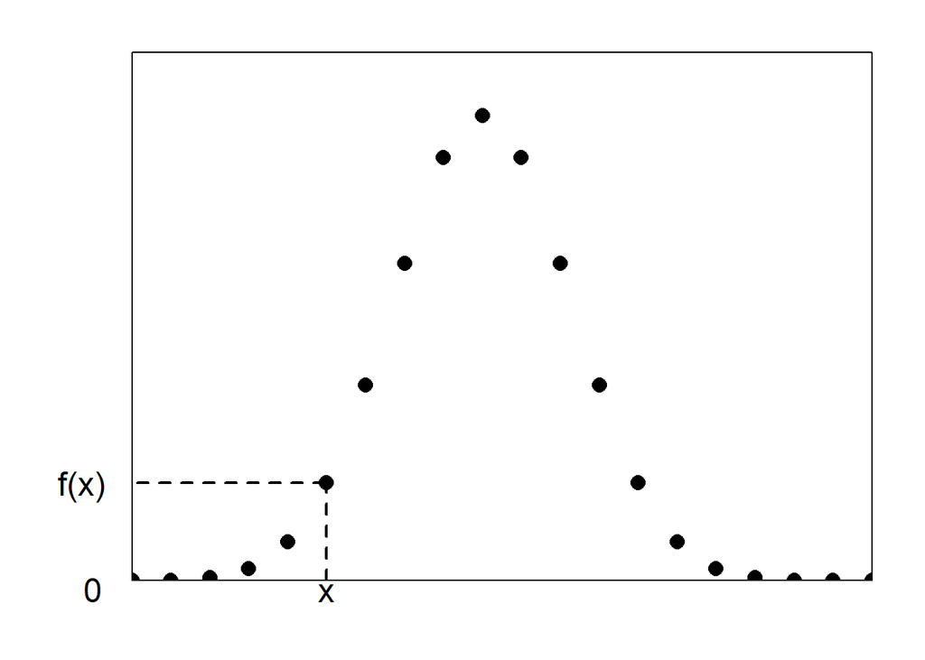

Figure 3.6: A mass function $f(x)$, plotted as distinct points $(x, f(x))$ for each possible value of the varible, $x \in J$. Values of $X$ between the plotted points $(x \notin J)$ are assumed to have zero probability ($f(x) = 0$).

### 3.2.1 Poisson distribution

**Example 3.4 (number of convictions)** Returning to the serial killers data, let’s consider a discrete variable: number of murders for which the killer was convicted. What is the probability that a randomly selected killer will have two or more convictions?

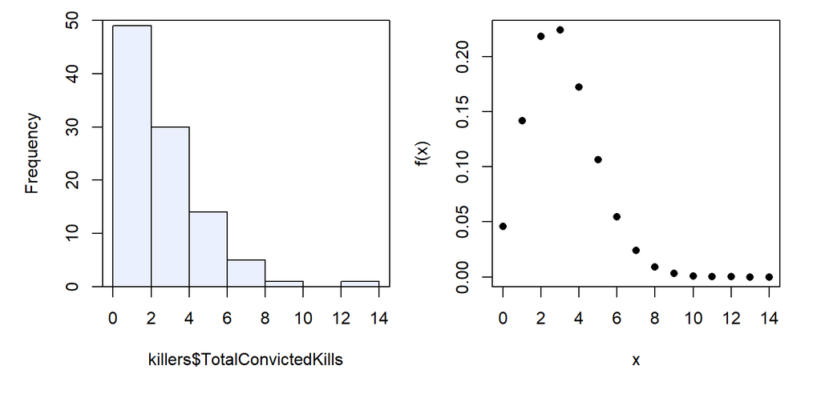

Figure 3.7: A histogram (left) of number of murder convictions, showing a non-negative sample with a clear positive skew. A Poisson distribution mass function (right), which might be a reasonable model for number of convictions given its similar shape to the histogram (non-negative, positive skew, and similar spread and location).

Of course, this variable can only take values in the non-negative integers and is therefore discrete. But we can still visualise these data using a histogram. We clearly need a distribution for a variable that takes only non-negative integer values and has a long tail to the right. The Poisson distribution seems like a good candidate.

**Definition 3.7** A random variable $X$ is said to have a **Poisson distribution** with rate parameter $\lambda >0$ if its mass function is
$$f(x) = \begin{cases} \lambda^{x}e^{-\lambda }/x! & x \in \{ 0,1,2,\ldots \}\\ 0 & \text{otherwise.}\end{cases}$$
We write $X\sim \text{Po}(\lambda)$.

**Notation.** Remember that “$x$ factorial” is $x! = 1\times 2\times 3 \times \ldots\times x$, and we set $0! = 1$.

The parameter $\lambda$ is called a “rate” because this distribution is often used to model counts of events that occur randomly, at a constant rate, within a given interval of time or space. For example, the number of decays per unit time in a radioactive sample.

**Solution to Example 3.4.** In our example, `sum(killers$TotalConvictedKills)` gives us a total of $308$ convictions among our $100$ killers. This suggests a rate of
$$\lambda \approx \frac{308}{100} = 3.08$$
convictions per killer and therefore we might take our model to be $X \sim \text{Po}(3.08)$. Thus, the probability of $2$ convictions or more would be
$${\mathsf P}(X \geq 2) = 1 - {\mathsf P}(X \leq 1)$$
where
$${\mathsf P}(X \leq 1) = \frac{3.08^{0}e^{-3.08}}{0!} + \frac{3.08^{1}e^{-3.08 }}{1!}
\approx 0.19$$
and therefore
$${\mathsf P}(X \geq 2) \approx 1 - 0.19 = 81\%.$$
We would get the same answer in R from `1 - ppois(q = 1, lambda = 3.08)`.

### 3.2.2 Binomial distribution

**Example 3.5 (insanity)** It is quite common for killers to plead “not guilty by reason of insanity” (NGRI). This is a form of **binary** data, only taking two possible values: the plea is successful or fails. Let’s assume that only around $8\%$ of NGRI pleas succeed. Among the next $20$ serial killers who plead NGRI, what is the probability that less than $2$ are successful?

Here we are assuming a “known” proportion, $p = 0.08$, among a hypothetical population of possible NGRI pleas. We imagine a random sample of size $n = 20$ from this population. The number of successes among them is unknown, so we model this as a random variable, $X$.

**Definition 3.8** A random variable $X$ is said to have a **binomial distribution** with size parameter $n \in \mathbb{N}$ and probability parameter $p \in (0,1)$ if its mass function is
$$f(x) %= \frac{n!}{x!(n-x)!}\,p^{x}\,(1-p)^{n-x}
= \binom{n}{x}\,p^{x}\,(1-p)^{n-x}$$
for $x \in \{ 0,1,2,\ldots n\}$ and $f(x) = 0$ otherwise. We write $X\sim \text{Bin}(n, p)$.

**Notation.** Remember that the binomial coefficient, “$n$ choose $x$”, is
$$\binom{n}{x} = \frac{n!}{x!(n-x)!}$$
for integers $0 \leq x \leq n$.

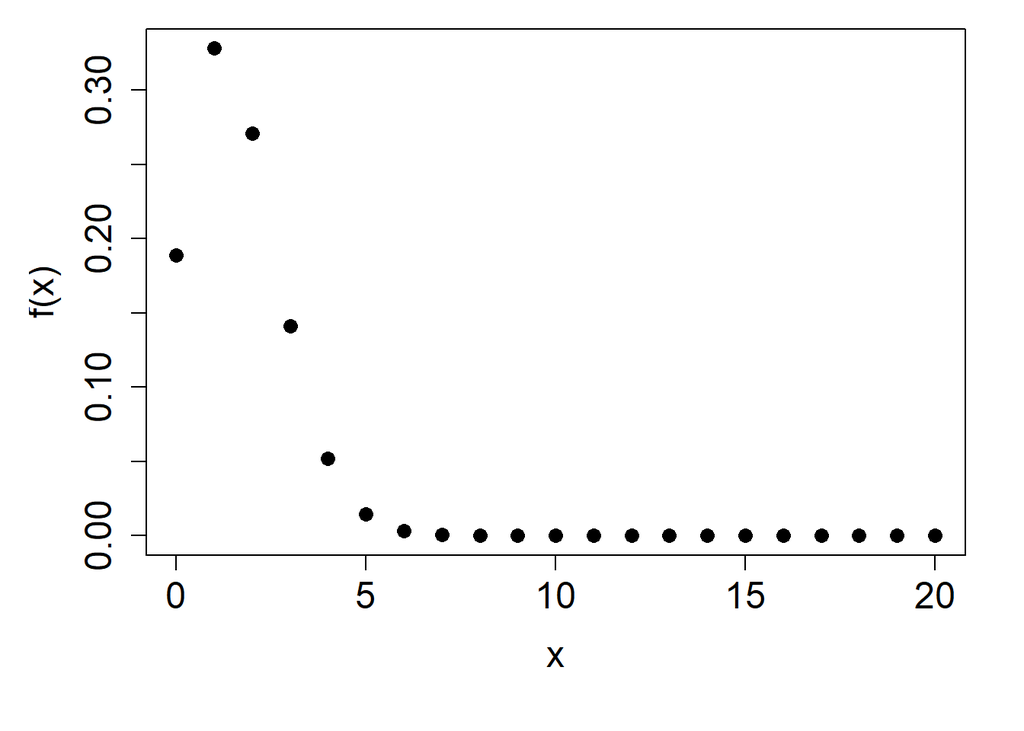

Figure 3.8: The binomial distribution mass function with size parameter $n = 20$ and probability parameter $p = 0.08$. For these parameter values the distribution has a strong positive skew, but it would be more symmetrical if, for example, $n$ was larger. The possible values of $x$ are integers from $0$ to $n$.

In general, a binomial distribution applies when we have:

- $n$ independent trials,
- probability of success $p$ in each trial,
- probability of failure $1 - p$ in each trial,
- and $X$ is the total number of successes in $n$ trials.

Note that a trial here can be any kind of experiment or event that has a binary outcome. Here the terms “trial”, “success” and “failure” are just labels. For example, we could use the binomial distribution to model the number of male victims in the next hundred murders by considering each murder to be a “trial”, each male victim to be a “success” and each female victim to be a “failure”. This does not imply that a male death is a positive outcome.

### 3.2.3 Geometric distribution

**Example 3.6 (insanity, continued)** Let’s continue to assume that $8\%$ of NGRI pleas succeed. How likely is it that exactly two will fail before one succeeds?

**Definition 3.9** A random variable $X$ is said to have a **geometric distribution** with parameter $p \in (0,1)$ if its mass function is
$$f(x) = p(1 - p)^{x}$$
for $x \in \{0, 1, \ldots \}$ and $f(x) = 0$ otherwise. We write $X\sim \text{Geom}(p)$.

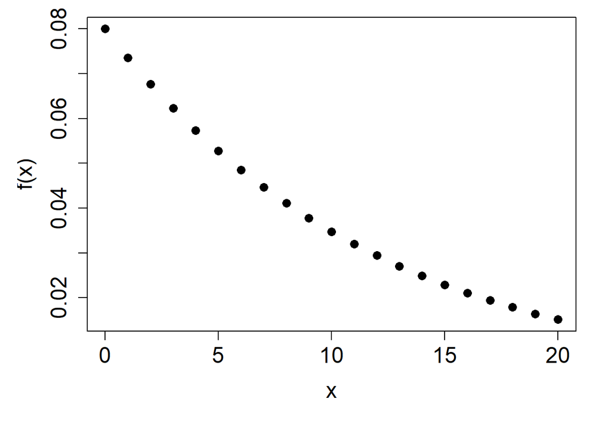

Figure 3.9: The geometric distribution mass function with probability parameter $p = 0.08$. As we would expect given how a geometric variable is defined we see that $f(x)$, the probability of $X = x$, decreases and approaches $0$ as $x$ increases from $0$ towards $\infty$.

In general, a geometric distribution applies when

- we carry out a sequence of consecutive, independent trials,
- each trial has probability of success $p$,
- each trial has probability of failure $1-p$,
- and $X$ is the **number of failed trials** until the **first successful** trial.

Please pay attention to the fact that $X$ only counts the failed trials, it does not include the successful trial.

**Solution to Example 3.6.** If we consider a successful NGRI plea to be a “successful trial”, then we have
$$X \sim \text{Geom}(0.08)$$
where $X$ denotes the number of failed pleas before the first success. The probability that we want is
$${\mathsf P}(X = 2) = f(2) = 0.08 \times (1 - 0.08)^{2} \approx 7\%.$$
This should not be confused with the probability that **at least** two consecutive pleas fail, ${\mathsf P}(X \geq 2)$. We can calculate this by first finding
$${\mathsf P}(X \leq 1) = \sum_{x = 0}^{1}f(x) = \sum_{x = 0}^{1} 0.08 \times 0.92^x = 0.08 \times 0.92^0 + 0.08 \times 0.92^1 \approx 15\%,$$
which implies that
$${\mathsf P}(X \geq 2) = 1 - {\mathsf P}(X \leq 1) \approx 85\%.$$

## 3.3 Continuous or discrete?

It is quite common to model discrete variables as continuous variables. For example, exam scores are discrete since they usually only take integer values from $0$ to $100$ (nobody gets an exam mark of $\pi$ or $\sqrt{2}$). However, this does not stop us from treating them as normally distributed when we need a model that can be used to predict student performance. Although the normal distribution does not fully reflect the nature of exam data, it can still be used as a model that gives us perfectly sensible probabilities, for example allowing us to calculate the probability of students obtaining a distinction, ${\mathsf P}(X \geq 70)$, just based on estimates of the mean and standard deviation obtained from past exam data. In fact, we are even happy to overlook the fact that the normal distribution would allow negative exam scores, which are impossible in reality, as long as the distribution only assigns a very small probability to such a possibility.

Similarly, we can sometimes model continuous variables using discrete probability distributions. For example, let $X$ be the life expectancy of a breed of dog. Although age is a continuous variable, we might only be interested in its value to the nearest year and the number of years has a fairly small range. Therefore we could consider a binomial distribution for $X$.

A model doesn’t have to be a perfect reflection of reality. It just has to do the job that it is intended for.

## 3.4 Properties of distributions

Distributions aim to model a hypothetical population. In our most recent examples, a population of serial killers. In our earlier examples, the population of all patients eligible for a surgery. A model allows us to calculate properties of the population, such as probabilities. But there are many other properties of interest, that can summarise important features of the population. For example, we might be interested in the average hospital stay duration following a surgery and how much hospital stay durations vary around this average.

### 3.4.1 Expectation

**Definition 3.10** The **expectation** (or **population mean** or **population average**) of a discrete random variable $X$ that takes values in a countable set $J$ is
$$\begin{equation*}
{\mathsf E}(X) = \sum_{x\in J}xf(x).
\end{equation*}$$

**Definition 3.11** The **expectation** (or **population mean** or **population average**) of a continuous random variable $X$ is
$$\begin{equation*}
{\mathsf E}(X) = \int_{-\infty }^{\infty }xf(x)dx.
\end{equation*}$$

**Example 3.7 (insanity, continued)** We previously modelled the number of successful NGRI (not guilty by reason of insanity) pleas in a sample of $20$ as $X \sim \text{Bin(20, 0.08)}$. What is the expected number of successful pleas in a sample of $20$? We know $X$ can only take values in $\{0,1,2,\ldots, 20\}$ and therefore
$$\begin{eqnarray*}
{\mathsf E}(X) & = & \sum_{x=0}^{20} x \binom{20}{x}0.08^{x}(1-0.08)^{20-x}\\
& = & 0 \binom{20}{0}0.08^{0}(1-0.08)^{20-0} + x \binom{20}{1}0.08^{1}(1-0.08)^{20-1} \\
&& +2 \binom{20}{2}0.08^{2}(1-0.08)^{20-2} + \ldots + 20 \binom{20}{20}0.08^{20}(1-0.08)^{20-20}.
\end{eqnarray*}$$

This is straightforward to calculate, but is quite a significant task by hand. An easier option is to derive a simple general formula for ${\mathsf E}(X)$ when $X\sim \text{Bin}(n,p)$:
$$\begin{eqnarray*}
{\mathsf E}(X) & = & \sum_{x=0}^{n} x \binom{n}{x}p^{x}(1-p)^{n-x}\\
& = & 0\binom{n}{0}p^{0}(1-p)^{n-0} + \sum_{x=1}^{n} x \binom{n}{x}p^{x}(1-p)^{n-x}\\
& = & \sum_{x=1}^{n} x \frac{n!}{x!(n-x)!}p^{x}(1-p)^{n-x}\\
& = & \sum_{x=1}^{n} \frac{n!}{(x-1)!(n-x)!}p^{x}(1-p)^{n-x}
\end{eqnarray*}$$
since $x/x! = x/(x\cdot (x-1) \cdots 2\cdot 1) = x/x(x-1)!$. This simplifies even further if we define $y = x - 1$,
$$\begin{eqnarray*}
{\mathsf E}(X) & = & \sum_{y=0}^{n-1} \frac{n!}{y!(n-y-1)!}p^{y + 1}(1-p)^{n-y -1} \\
& = & np \sum_{y=0}^{n-1} \frac{(n-1)!}{y!([n-1]-y)!}p^{y}(1-p)^{[n-1]-y} \\
& = & np \sum_{y=0}^{n-1} \binom{n-1}{y}p^{y}(1-p)^{[n-1]-y} \\
& = & np \sum_{y=0}^{n-1} f(y)
\end{eqnarray*}$$
where $f(y)$ is the mass of $Y \sim Bin(n-1, p)$ and therefore sums to $1$ by the general properties of mass functions. This gives
$$\begin{eqnarray*}
{\mathsf E}(X) & = & np.
\end{eqnarray*}$$
Now we can use this very simple formula for **any** binomially distributed variable $X\sim \text{Bin}(n,p)$, whatever the values of its parameters are. In our example, this gives an expectation of ${\mathsf E}(X) = 20\times 0.08 = 1.6$ successes per $20$ pleas made.

**Theorem 3.2** If $X$ is a random variable and $h:\mathbb{R}\rightarrow \mathbb{R}$ is any function, then
$$\begin{equation*}
{\mathsf E}\left[ h(X) \right] =\Bigg\{ \begin{array}{cl} \sum_{x\in J} h(x) f(x) & \text{if }X\text{ is discrete,} \\
\int_{-\infty}^{\infty} h(x)f(x) dx & \text{if }X\text{ is continuous,}
\end{array}
\end{equation*}$$
where $f(x)$ is the density or mass function of $X$.

But we **cannot say** that ${\mathsf E}(h(X)) = h({\mathsf E}(X))$ in general. The expectation of a function of $X$ cannot necessarily be obtained by applying that function to the expectation of $X$.

However, expectation does have nice properties such as **linearity**:
$$\begin{eqnarray*}
{\mathsf E}(aX+b) &=& a \, {\mathsf E}(X) + b
\end{eqnarray*}$$
if $a$ and $b$ are constants. This can be very helpful, for example when we change the units of a variable, since it means that we don’t have to redo the entire calculation.

The expectation gives us the “average value” of a random variable across the entire distribution. We can also think of it as the “centre of mass” of the distribution. But we often need more information than this. For example, let $X$ denote time to death following a surgery. Let $Y$ be time to death following a new, experimental surgery to treat the same illness. If ${\mathsf E}(X) = {\mathsf E}(Y)$, can we conclude that there is no reason to prefer the either surgery? Not if $X$ is much more varied than $Y$. In that case the new surgery might be preferred for its consistency. To make such comparisons, we need some property that provides a measure of the variability of a random variable. This will be the focus of the next subsection.

### 3.4.2 Variance

In addition to the expectation, we need some way to measure the spread/variability a random variable. We achieve this by considering the squared distance of $X$ from its expectation $[X - {\mathsf E}(X)]^{2}$ and taking the expectation of this random quantity.

**Definition 3.12** The **variance** of a random variable $X$ is
$$\begin{equation*}
\text{var}(X) = {\mathsf E}\left( \left[ X-{\mathsf E}(X) \right]^{2}\right) = {\mathsf E}(X^{2}) - \left[ {\mathsf E}(X) \right]^{2}.
\end{equation*}$$
The **standard deviation** of $X$ is $\sqrt{\text{var}(X)}$.

**Note.** The second expression for the variance is the most useful in practice.

Unlike expectation, variance is not a linear operator. However, it can be shown that
$$\begin{equation*}
\text{var}(aX+b) = a^2\,\text{var}(X)
\end{equation*}$$
if $a$ and $b$ are constants. In other words, the variance is unaffected adding a constant, but scaling by a factor of $a$ inflates the variance by a factor $a^2$.

**Example 3.8 (surgery duration)** Suppose that length of time taken to perform a particular type of surgery (in minutes) is exponentially distributed, $X \sim \text{Exp}(\lambda)$. What are the mean and variance? We have
$$f(x) = \lambda\exp(-\lambda x)$$
for $x > 0$ and $f(x) = 0$ for $x \leq 0$. Using integration by parts,
$$\begin{eqnarray}
{\mathsf E}(X) & = & {\int_{-\infty}^{\infty} xf(x)dx} \\
& = & {\int_{-\infty}^{0} x\underbrace{f(x)}_{=0}dx + \int_{0}^{\infty} xf(x)dx} \\
& = & \int_{0}^{\infty}x\lambda e^{-\lambda x}dx\nonumber\\
& = & \left[-x e^{-\lambda x} + \int e^{-\lambda x}dx \right]_{0}^{\infty}\nonumber\\
& = & \left[-x e^{-\lambda x} - e^{-\lambda x}/\lambda \right]_{0}^{\infty}\nonumber\\
%& = & 0 + e^{0}/\lambda\nonumber\\
& = & 1/\lambda\nonumber
\end{eqnarray}$$
and, by Theorem 4,
$$\begin{eqnarray}
{\mathsf E}(X^{2}) & = & {\int_{-\infty}^{\infty} x^2f(x)dx} \\
& = & {\int_{-\infty}^{0} x^2\underbrace{f(x)}_{=0}dx + \int_{0}^{\infty} x^2f(x)dx} \\
& = &\int_{0}^{\infty}x^{2}\lambda e^{-\lambda x}dx\nonumber\\
& = & \left[-x^{2} e^{-\lambda x} + \int 2xe^{-\lambda x}dx \right]_{0}^{\infty}\nonumber\\
& = & \left[-x^{2} e^{-\lambda x} \right]_{0}^{\infty} + \frac{2}{\lambda}\int^{\infty}_{0} x\lambda e^{-\lambda x}dx\nonumber\\
& = & 0 + \frac{2}{\lambda}{\mathsf E}(X)\nonumber\\
& = & \frac{2}{\lambda^{2}}.\nonumber
\end{eqnarray}$$
Therefore ${\mathsf E}(X) = 1/\lambda$ and $\text{var}(X) = (2/\lambda^{2}) - (1/\lambda)^{2} = 1/\lambda^{2}$.

## 3.5 Summations

It is also very common that we need to work with sums of random variables. For example, if $100$ patients will undergo surgery, what are the expectation and variance of the total surgery duration of these patients? For two random variables $X$ and $Y$, we can easily show that
$${\mathsf E}(X + Y) = {\mathsf E}(X) + {\mathsf E}(Y).$$
If the variables are **independent** then
$$\text{var}(X + Y) = \text{var}(X) + \text{var}(Y).$$
These ideas generalise easily to an arbitrary number of random variables, as seen in the following theorem.

**Theorem 3.3** Let $X_{1}, \ldots, X_{n}$ be $n$ random variables, then
$${\mathsf E}\left(\sum_{i=1}^{n}X_{i}\right) = \sum_{i=1}^{n}{\mathsf E}(X_{i})$$
and if they are **independent** then
$$\begin{eqnarray}
\text{var}\left(\sum_{i=1}^{n}X_{i}\right) = \sum_{i=1}^{n}\text{var}(X_{i}).\nonumber
\end{eqnarray}$$

**Example 3.9 (surgery duration, continued)** Suppose that $\lambda = 0.02$, then the mean surgery duration is $50$ minutes and the variance is $2500$ minutes$^2$. If $100$ patients are scheduled for surgery, then we have
$$\begin{eqnarray*}
{\mathsf E}\left(\sum_{i=1}^{100}X_i\right) & = & \sum_{i=1}^{100}{\mathsf E}\left(X_i\right)\\
& = & \sum_{i=1}^{100}50 \\
& = & 100\times 50\\
& = & 5000 \text{ minutes}
\end{eqnarray*}$$
and, similarly,
$$\begin{eqnarray*}
\text{var}\left(\sum_{i=1}^{100}X_i\right) & = & \sum_{i=1}^{100}\text{var}\left(X_i\right)\\
& = & \sum_{i=1}^{100}2500\\
& = & 100\times 2500 = 250000.
\end{eqnarray*}$$

In the case of independent, **normally distributed** random variables, we have a further helpful fact:
$$X \sim N(\mu_1, \sigma^2_1) \; \text{and} \; Y \sim N(\mu_2, \sigma^2_2) \;\; \Rightarrow \;\; X + Y \sim N(\mu_1 + \mu_2, \sigma^2_1 + \sigma^2_2).$$
This gives us more than just the mean and variance of a sum of variables, it gives us the ability to calculate **probabilities** for that sum. More generally, we have the following theorem.

**Theorem 3.4** Let $X_1, \ldots, X_n$ be **independent** random variables with $X_i \sim N(\mu_i , \sigma^2_i)$ for $i = 1, \ldots, n$, then
$$\sum_{i = 1}^{n}X_i \sim N\left(\sum_{i = 1}^{n}\mu_i\;,\; \sum_{i = 1}^{n}\sigma^2_i\right).$$
If they are **independent and identically distributed**, with $X_i \sim N(\mu, \sigma^2)$, then
$$\sum_{i = 1}^{n}X_i \sim N\left(n\mu\;,\; n\sigma^2\right).$$

## 3.6 Parameters

As we have seen in the examples of this section, we can often derive the expectation and variance of a random variable in terms of the parameters of its probability distribution. For the distributions in this section, these are all listed in the table below (you can try to derive each of these as an exercise - the solutions can be found in many books and even Wikipedia).

| Distribution | Parameters | Expectation | Variance |
| --- | --- | --- | --- |
| Normal | $\mu$ and $\sigma^2$ | $\mu$ | $\sigma^2$ |
| Exponential | $\lambda$ | $1/\lambda$ | $1/\lambda^2$ |
| Uniform | $a$ and $b$ | $(a + b)/2$ | $(b - a)^2/12$ |
| Poisson | $\lambda$ | $\lambda$ | $\lambda$ |
| Binomial | $n$ and $p$ | $np$ | $np(1-p)$ |
| Geometric | $p$ | $(1-p)/p$ | $(1-p)/p^2$ |

Similarly, we have seen how to derive probabilities in terms of parameters. It is therefore clear that the important properties of a distribution very often depend its parameters. However, these parameters are usually **unknown** in practice. Without knowing their values, we will be unable to fully understand the distribution. For example, how could we sensibly comment on the obesity epidemic in a country if we had no idea of the average body mass index, or its variance, in that country? If we hope for statistical models based on these distributions to be of any practical use, a priority in our analyses should be to **estimate** these parameters. This will be the focus of the next chapter.

[^1]: A small amount of random noise has been added to the `killers.Rdata` data set, since researchers must have permission to access the original data.